# Predicción Ventas de Apple. ETS & ARIMA

Beatriz Cárdaba

16/11/2020

# Import Data

```
## # A tibble: 6 x 2
##   Trimestre Ingresos
##   <chr>        <dbl>
## 1 Q2 2008       7980
## 2 Q3 2008       7561
## 3 Q4 2008      11520
## 4 Q1 2009      11880
## 5 Q2 2009       9084
## 6 Q3 2009       9734
```

# ETS

El objetivo es la creación de un modelo a partir de de las componentes: errores, tendendencia y estacionalidad. Que pueden ser multiplicativos o aditivos (y aditivos suavizados).

## Transformación de Datos

Hay que convertir el data farme con los datos en un modelo de tabla XTS. Unos df especiales donde el índice de los datos está generado por un índice de tiempo.

- Transformamos a XTS

Se cambia el índice de la tabla por la unidades de tiempo.

```
##             [,1]
## 2008-04-01  7980
## 2008-07-01  7561
## 2008-10-01 11520
## 2009-01-01 11880
## 2009-04-01  9084
## 2009-07-01  9734
```

- Transformamos en datos trimestrales

El índice temporal en este caso deber ser trimestral.

- Transformamos a zoo Data:
- Visualizar gráficamente los datos para explorar las posibles tendencias:

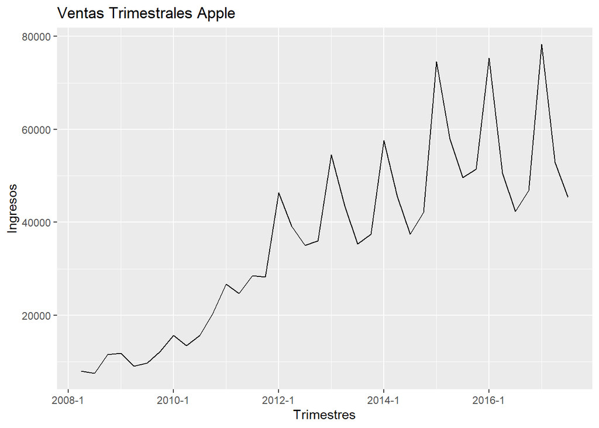

En este caso se observa una tendencia creciente de los datos.

Se visualiza si los datos tienen alguna componente estacional, para ello se transforman los datos mediante una media estacionaria.

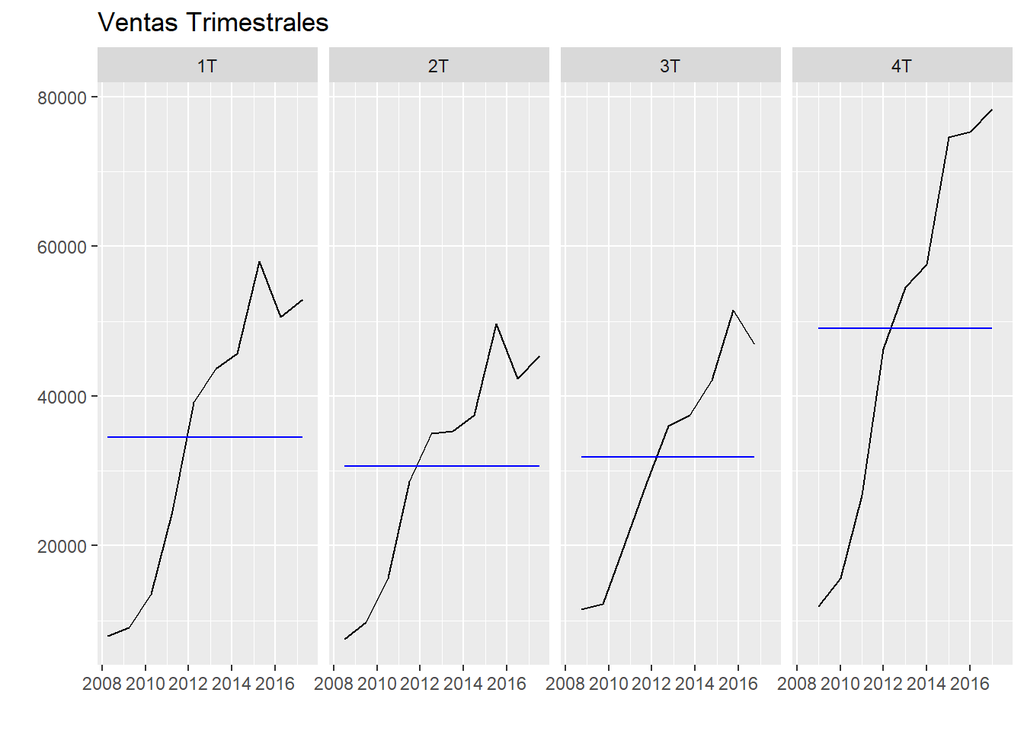

Se observa un comportomiento estacional ya que las medias se comportan diferente en función del trimestre, Sobre todo destaca el incremento de las ventas en el cuarto trimestre a partir del año 2012. Además el promedio de las ventas del primer trimestre es superior a las evntas en el Q2 y Q3.

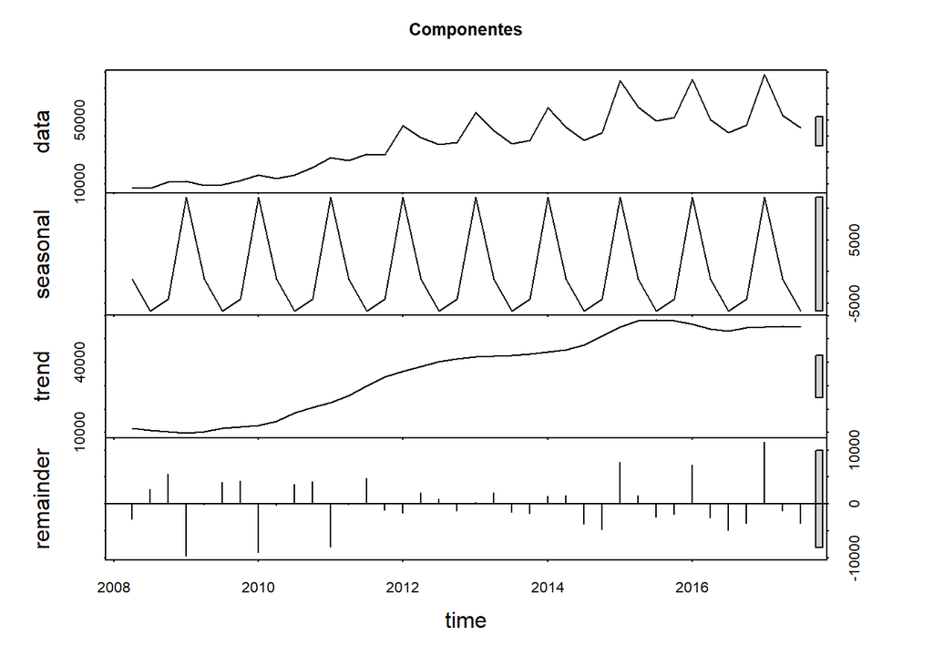

Tras la visualización de estos gráficos se puede concluir que los ingresoso de Apple muestran una tendencia positiva con estacionalidad. Vemos como cada año los ingresos medios van aumentando y como en varían estos de forma parecida en cada trimestre, siendo los Q4 y Q1 de cada año cuando más ventas se realizan coincidiendo con la campaña navideña.

## Predicción:

**Seleción de muestra:**

En primer lugar, se deben seleccionar los datos con los que vamos a realizar el modelo predictivo. Para este modelo dejaremos fuera del entrenamiento las observacines del último año, por lo tanto los tres últimos trimestres de los que existen datos, ya que finalizan en 2017Q3.

### Selección Automática del modelo ETS

Se utiliza la fórmula ets que selecciona automáticamente el mejor modelo ETS.

Estos son los datos que predice:

```
##
## Forecast method: ETS(M,A,M)
##
## Model Information:
## ETS(M,A,M)
##
## Call:
##  ets(y = muestra)
##
##   Smoothing parameters:
##     alpha = 0.493
##     beta  = 0.493
##     gamma = 0.507
##
##   Initial states:
##     l = 7125.3462
##     b = 1485.7975
##     s = 1.1511 1.1163 0.8322 0.9004
##
##   sigma:  0.1222
##
##      AIC     AICc      BIC
## 703.9538 711.1538 717.9519
##
## Error measures:
##                   ME     RMSE      MAE       MPE     MAPE      MASE      ACF1
## Training set -41.934 4120.155 2883.262 -0.297759 8.677434 0.4160202 0.1438481
##
## Forecasts:
##         Point Forecast     Lo 80     Hi 80      Lo 95     Hi 95
## 2017 Q1       69439.83 58568.387  80311.27  52813.394  86066.26
## 2017 Q2       53347.98 41773.016  64922.95  35645.598  71050.37
## 2017 Q3       48972.04 33884.613  64059.47  25897.811  72046.27
## 2017 Q4       54176.09 31475.035  76877.14  19457.824  88894.35
## 2018 Q1       80540.07 32680.293 128399.85   7344.857 153735.28
## 2018 Q2       61619.03 17211.212 106026.85  -6296.866 129534.93
## 2018 Q3       56344.41  7869.773 104819.05 -17791.151 130479.97
## 2018 Q4       62103.80  -718.363 124925.97 -33974.410 158182.02
```

En el modelo ETS la distribución de los errores es Multiplicativa , la tendencia aditiva y la estacionalidad multiplicativa. También es conocido este nmétodo ets como: *“Multiplicative Holt-Winters’ methodwith multiplicative errors”* Graficamos los datos reales vs el forecast que predice

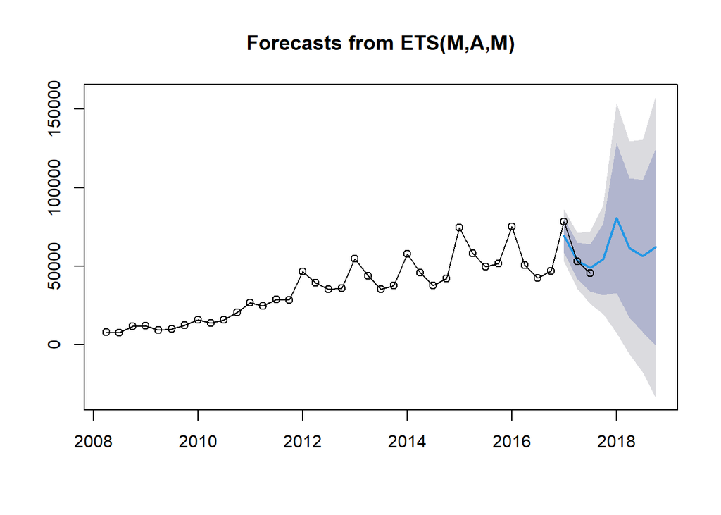

Comparamos los datos reales de 2017 con su predicción por trimestres:

```
##          [,1]  [,2]
## [1,] 69439.83 78351
## [2,] 53347.98 52896
## [3,] 48972.04 45408
```

# ARIMA

Box y Jenkins desarrollaron modelos estadísticos para series temporales que tienen en cuenta la de pendencia existente entre los datos, esto es cada observación en un momento dada es modelada en función de los valores anteriores. Los análisis se basan en un modelo explícito. LOs modelos se conocen con el nombre genérico de ARIMA (Autoregresive Interegated Moving Average), que deriva del modelo Autoregresivo que tiene en cuenta los pvalroes de los periodos anteriores , el modelo Integrado, y del modelo MA que tiene en cuenta los errores en los periodos anteriores.

### Predicción

**Seleción Automática del modelo ARIMA:**

Hay que seleccionar el modelo ARIMA (p,d,q)(P,D,Q). Donde (p,d,q) se refiere a la parte no estacional del modelo y (P,D,Q) se refiere a las variaciones estacionales del modelo. Seleccionamos este modelo de manera automática:

o Nonseasonal order: Número de diferencias regulares d o Seasonal order: Numero de diferencias estacionales D o AR: Orden del autorregresivo regular p o MA: Orden de la media móvil regular q o SAR: Orden del autorregresivo estacional P o SMA: Orden de la media móvil estacional Q

```
## Series: muestra
## ARIMA(1,0,0)(0,1,0)[4]
##
## Coefficients:
##          ar1
##       0.8331
## s.e.  0.0876
##
## sigma^2 estimated as 20474541:  log likelihood=-305.01
## AIC=614.02   AICc=614.45   BIC=616.89
##
## Training set error measures:
##                    ME     RMSE      MAE      MPE     MAPE      MASE       ACF1
## Training set 716.2193 4189.225 2797.277 2.986021 8.038297 0.4036137 0.05639445
```

Visualizamos el modelo:

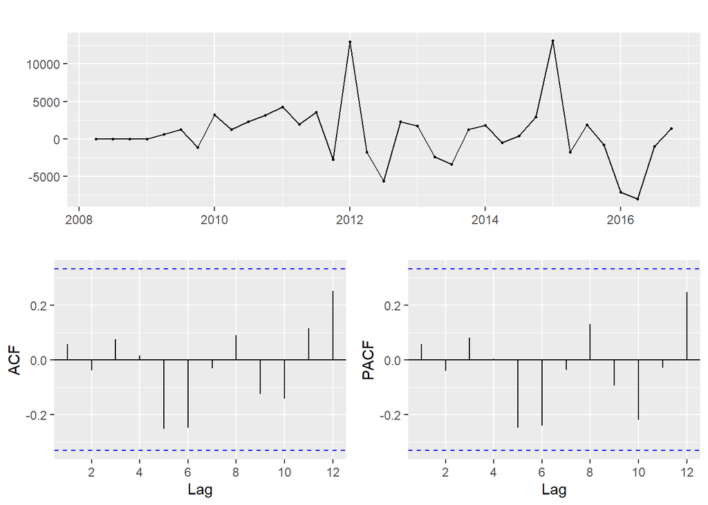

Se observa que tanto los errores en ACF y en PACF se encuentran entre las bandas, cumplen las exigencias.

**BOX_LJUNG TEST:** El test Box-Ljung consiste en contrastar si los retardos de la acf son cero a la vez:

```
##
##  Box-Ljung test
##
## data:  fit_arima$residuals
## X-squared = 0.40409, df = 2, p-value = 0.8171
```

```
##
##  Box-Ljung test
##
## data:  fit_arima$residuals
## X-squared = 5.8942, df = 5, p-value = 0.3167
```

```
##
##  Box-Ljung test
##
## data:  fit_arima$residuals
## X-squared = 12.447, df = 11, p-value = 0.331
```

El p-valor > 0.05 por lo que es Ruido Blanco.

### Predicción de Ventas

Predecimos las ventas con el modelo arima elegido automáticamente:

```
##
## Forecast method: ARIMA(1,0,0)(0,1,0)[4]
##
## Model Information:
## Series: muestra
## ARIMA(1,0,0)(0,1,0)[4]
##
## Coefficients:
##          ar1
##       0.8331
## s.e.  0.0876
##
## sigma^2 estimated as 20474541:  log likelihood=-305.01
## AIC=614.02   AICc=614.45   BIC=616.89
##
## Error measures:
##                    ME     RMSE      MAE      MPE     MAPE      MASE       ACF1
## Training set 716.2193 4189.225 2797.277 2.986021 8.038297 0.4036137 0.05639445
##
## Forecasts:
##         Point Forecast    Lo 80    Hi 80    Lo 95    Hi 95
## 2017 Q1       71450.81 65651.94 77249.68 62582.21 80319.41
## 2017 Q2       47330.16 39782.50 54877.81 35787.02 58873.30
## 2017 Q3       39669.64 31115.85 48223.43 26587.74 52751.54
## 2017 Q4       44612.27 35424.67 53799.86 30561.05 58663.48
## 2018 Q1       69584.84 57005.32 82164.35 50346.13 88823.54
## 2018 Q2       45775.57 31301.78 60249.36 23639.82 67911.33
## 2018 Q3       38374.48 22720.07 54028.89 14433.13 62315.83
## 2018 Q4       43533.24 27109.19 59957.29 18414.82 68651.65
```

Representación gráfica de los resultados de la predcción del modelo ARIMA:

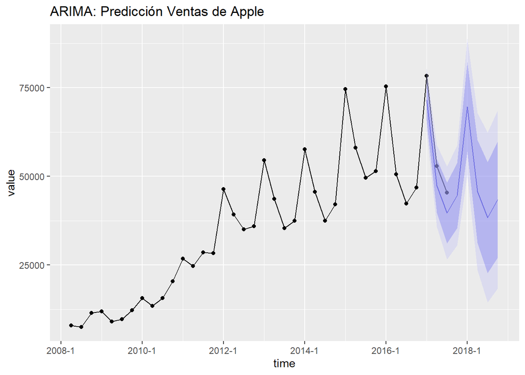

# COMPARACIÓN ETS vs ARIMA

En primer lugar se comparan los errores:

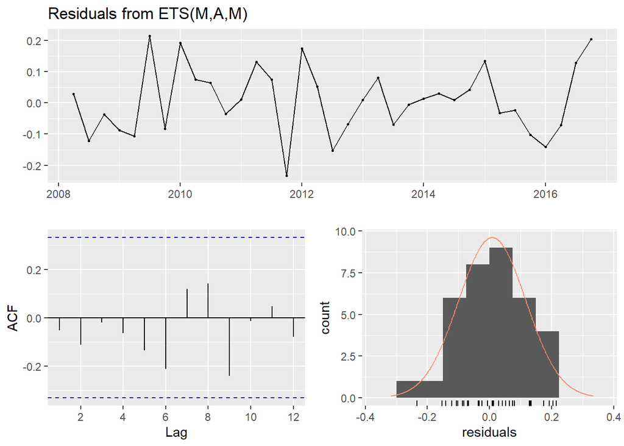

```
##
##  Ljung-Box test
##
## data:  Residuals from ETS(M,A,M)
## Q* = 8.2079, df = 3, p-value = 0.0419
##
## Model df: 8.   Total lags used: 11
```

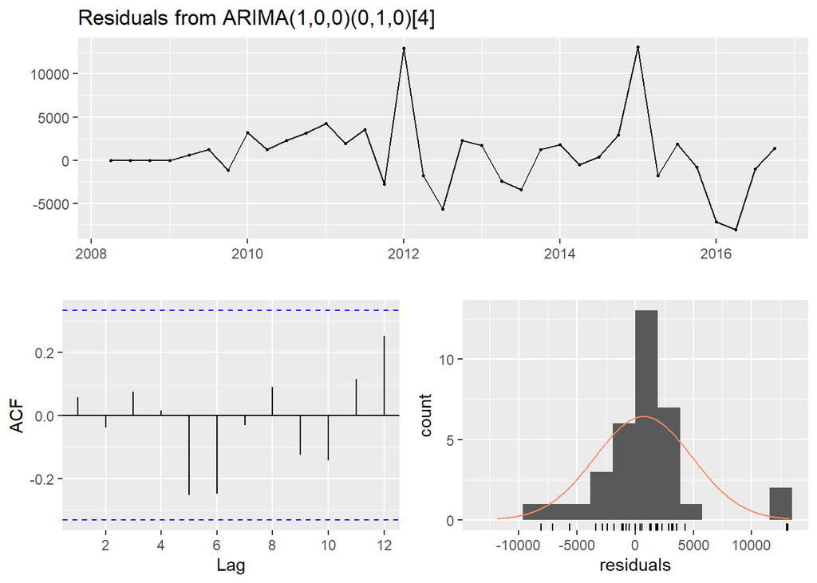

```
##
##  Ljung-Box test
##
## data:  Residuals from ARIMA(1,0,0)(0,1,0)[4]
## Q* = 5.9372, df = 6, p-value = 0.4303
##
## Model df: 1.   Total lags used: 7
```